# Simple Linear Regression

Adam Caffrey

04/01/2021

Linear regression is the simplest machine learning concept one should know. On this page, I use linear regression to estimate the length of petals using the famous iris dataset and in doing so will layout the typical machine learning workflow.

```r
data <- iris
```

The data consists of 5 columns, 4 numeric and 1 nominal. For this example I shall create a linear model to predict the petal length from the petal width. No data is missing and no cleaning is necessary for this dataset.

```r
glimpse(data)
```

```
## Rows: 150
## Columns: 5
## $ Sepal.Length <dbl> 5.1, 4.9, 4.7, 4.6, 5.0, 5.4, 4.6, 5.0, 4.4, 4.9, 5.4, 4.…
## $ Sepal.Width  <dbl> 3.5, 3.0, 3.2, 3.1, 3.6, 3.9, 3.4, 3.4, 2.9, 3.1, 3.7, 3.…
## $ Petal.Length <dbl> 1.4, 1.4, 1.3, 1.5, 1.4, 1.7, 1.4, 1.5, 1.4, 1.5, 1.5, 1.…
## $ Petal.Width  <dbl> 0.2, 0.2, 0.2, 0.2, 0.2, 0.4, 0.3, 0.2, 0.2, 0.1, 0.2, 0.…
## $ Species      <fct> setosa, setosa, setosa, setosa, setosa, setosa, setosa, s…
```

Data is first split into a testing and training set using the rsample package:

```r
data_split <- initial_split(data, prop = 3/4)
data_train <- training(data_split)
data_test <- testing(data_split)
```

A linear model is selected from the **lm** library…

```r
lr_model <-
  linear_reg() %>%
  set_engine("lm")
```

…and a very simple recipe is produced.

```r
lr_recipe <- recipe(Petal.Length ~ Petal.Width, data_train)
```

A workflow object is used to combine the model and recipe. This also removes the need to **prep** and **bake** the recipe:

```r
lr_wf <-
  workflow() %>%
  add_model(lr_model) %>%
  add_recipe(lr_recipe)
```

The **fit** method then uses the training data to establish a model. The **lr_fit** object contains the model coefficients.

```r
(lr_fit <- fit(lr_wf, data_train))
```

```
## ══ Workflow [trained] ══════════════════════════════════════════════════════════
## Preprocessor: Recipe
## Model: linear_reg()
##
## ── Preprocessor ────────────────────────────────────────────────────────────────
## 0 Recipe Steps
##
## ── Model ───────────────────────────────────────────────────────────────────────
##
## Call:
## stats::lm(formula = ..y ~ ., data = data)
##
## Coefficients:
## (Intercept)  Petal.Width
##       1.089        2.237
```

Using this model we can now predict the length of petals using the test data.

```r
(pred <- predict(lr_fit, data_test) %>%
  select(.pred) %>%
  bind_cols(., "truth" = data_test$Petal.Length,
            "resid" = data_test$Petal.Length - .$.pred))
```

```
## # A tibble: 38 × 3
##    .pred truth   resid
##    <dbl> <dbl>   <dbl>
##  1  1.54   1.4 -0.137
##  2  1.54   1.5 -0.0367
##  3  1.54   1.2 -0.337
##  4  1.98   1.5 -0.484
##  5  1.76   1.5 -0.260
##  6  1.54   1.7  0.163
##  7  1.98   1.5 -0.484
##  8  1.98   1.5 -0.484
##  9  1.54   1.5 -0.0367
## 10  2.43   1.6 -0.831
## # … with 28 more rows
```

The performance of linear models are typically graded using rmse, rsq and mae values. These are obtained using the **metrics** method.

```r
pred %>%  metrics(truth = truth, estimate = .pred)
```

```
## # A tibble: 3 × 3
##   .metric .estimator .estimate
##   <chr>   <chr>          <dbl>
## 1 rmse    standard       0.505
## 2 rsq     standard       0.916
## 3 mae     standard       0.397
```

A more intuitive visualisation can be obtained by plotting the predicted values against the actual values [left]. The diagonal line has a slope of 1 indicating an exact match. A good match is found between predicted and actual values. Additionally, linear regression requires homoscedasticity (constant variance amongst errors). This behaviour is displayed below [right] though few data points are available to be conclusive.

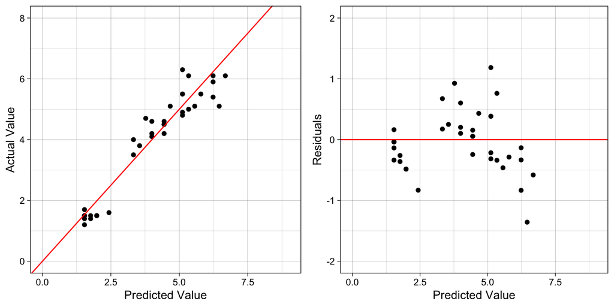

```r
ggplt1 <-
  ggplot(data = pred, aes(x = .pred, y = truth)) +
    geom_point() +
    geom_abline(slope = 1, col = "red") +
    theme_linedraw() +
    labs(x = "Predicted Value", y = "Actual Value") +
    lims(x = c(0,9), y = c(0,8))

ggplt2 <-
  ggplot(data = pred, aes(x = .pred, y = resid)) +
    geom_point() +
    geom_abline(slope = 0, intercept = 0, col = "red") +
    theme_linedraw() +
    labs(x = "Predicted Value", y = "Residuals") +
    lims(x = c(0,9), y = c(-2,2))

gridExtra::grid.arrange(ggplt1, ggplt2, nrow = 1)
```

This simple introduction to linear regression highlights the following tidymodels concepts:  
1. workflow objects  
2. recipe creation  
3. model selection  
4. data fitting  
5. data prediction  
6. model evaluation